# Retailer Forecast

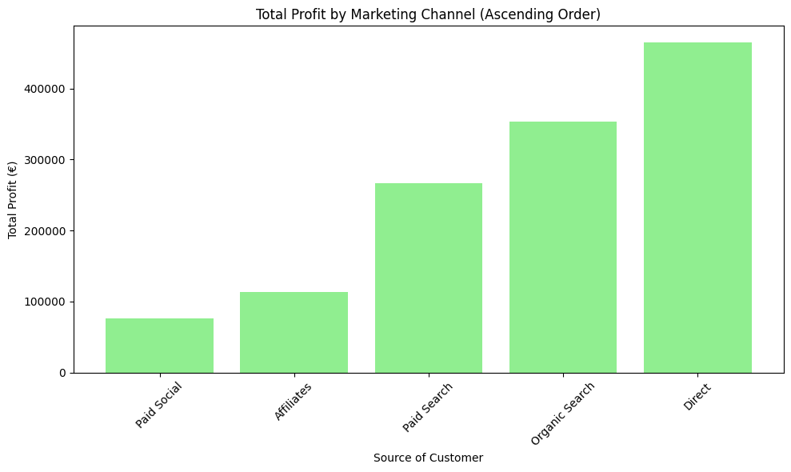

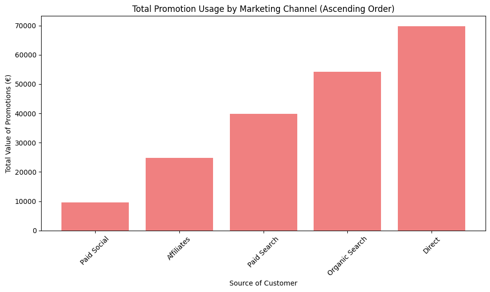

```python
import pandas as pd
import matplotlib.pyplot as plt

# Step 1: Calculate total profit for each customer (1st Order Profit + Subsequent Order Profit)
merged_df['Total Profit'] = merged_df['1st Order Profit'] + merged_df['Subsequent Order Profit'] - merged_df["Total value of all promotions"]

# Step 2: Group by 'Source of Customer' to calculate the total profit for each channel
total_profit_by_channel = merged_df.groupby('Source of Customer')['Total Profit'].sum().reset_index()

# Step 3: Group by 'Source of Customer' to calculate the total value of promotions used for each channel
promotion_usage_by_channel = merged_df.groupby('Source of Customer')['Total value of all promotions'].sum().reset_index()

# Step 4: Sort total profit and promotion usage by ascending order
total_profit_by_channel = total_profit_by_channel.sort_values(by='Total Profit', ascending=True)
promotion_usage_by_channel = promotion_usage_by_channel.sort_values(by='Total value of all promotions', ascending=True)

# Step 5: Plot total profit by channel (sorted in ascending order)
plt.figure(figsize=(10, 6))
plt.bar(total_profit_by_channel['Source of Customer'], total_profit_by_channel['Total Profit'], color='lightgreen')
plt.title('Total Profit by Marketing Channel (Ascending Order)')
plt.xlabel('Source of Customer')
plt.ylabel('Total Profit (€)')
plt.xticks(rotation=45)
plt.tight_layout()
plt.show()

# Step 6: Plot promotion usage by channel (sorted in ascending order)
plt.figure(figsize=(10, 6))
plt.bar(promotion_usage_by_channel['Source of Customer'], promotion_usage_by_channel['Total value of all promotions'], color='lightcoral')
plt.title('Total Promotion Usage by Marketing Channel (Ascending Order)')
plt.xlabel('Source of Customer')
plt.ylabel('Total Value of Promotions (€)')
plt.xticks(rotation=45)
plt.tight_layout()
plt.show()
```

Doing the same for percentage this time:

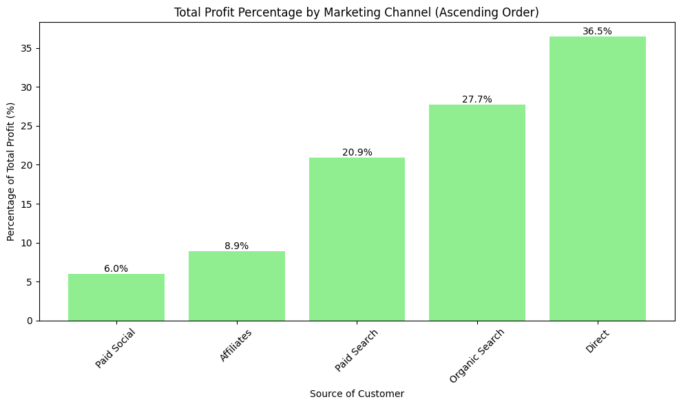

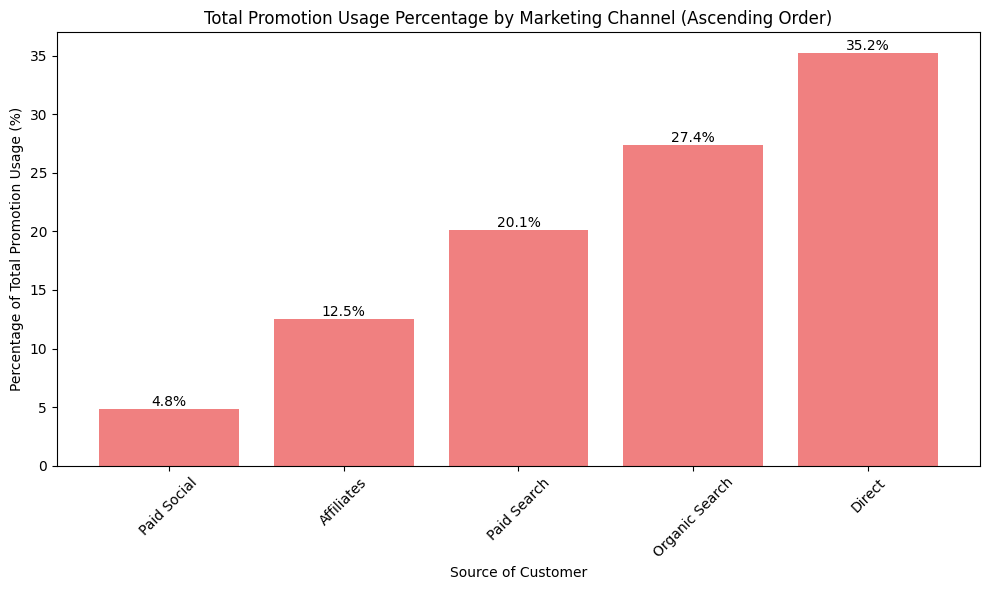

```python
# Step 1: Calculate total profit for each customer (1st Order Profit + Subsequent Order Profit)
merged_df['Total Profit'] = merged_df['1st Order Profit'] + merged_df['Subsequent Order Profit'] - merged_df["Total value of all promotions"]

# Step 2: Group by 'Source of Customer' to calculate the total profit for each channel
total_profit_by_channel = merged_df.groupby('Source of Customer')['Total Profit'].sum().reset_index()

# Step 3: Group by 'Source of Customer' to calculate the total value of promotions used for each channel
promotion_usage_by_channel = merged_df.groupby('Source of Customer')['Total value of all promotions'].sum().reset_index()

# Step 4: Sort total profit and promotion usage by ascending order
total_profit_by_channel = total_profit_by_channel.sort_values(by='Total Profit', ascending=True)
promotion_usage_by_channel = promotion_usage_by_channel.sort_values(by='Total value of all promotions', ascending=True)

# Step 5: Calculate percentage for total profit and promotion usage
total_profit_sum = total_profit_by_channel['Total Profit'].sum()
promotion_usage_sum = promotion_usage_by_channel['Total value of all promotions'].sum()

total_profit_by_channel['Percentage'] = (total_profit_by_channel['Total Profit'] / total_profit_sum) * 100
promotion_usage_by_channel['Percentage'] = (promotion_usage_by_channel['Total value of all promotions'] / promotion_usage_sum) * 100

# Step 6: Plot total profit percentage by channel (sorted in ascending order)
plt.figure(figsize=(10, 6))
bars = plt.bar(total_profit_by_channel['Source of Customer'], total_profit_by_channel['Percentage'], color='lightgreen')
plt.title('Total Profit Percentage by Marketing Channel (Ascending Order)')
plt.xlabel('Source of Customer')
plt.ylabel('Percentage of Total Profit (%)')
plt.xticks(rotation=45)
plt.tight_layout()

# Display percentage labels on bars
for bar in bars:
    height = bar.get_height()
    plt.text(bar.get_x() + bar.get_width()/2.0, height, f'{height:.1f}%', ha='center', va='bottom')

plt.show()

# Step 7: Plot promotion usage percentage by channel (sorted in ascending order)
plt.figure(figsize=(10, 6))
bars = plt.bar(promotion_usage_by_channel['Source of Customer'], promotion_usage_by_channel['Percentage'], color='lightcoral')
plt.title('Total Promotion Usage Percentage by Marketing Channel (Ascending Order)')
plt.xlabel('Source of Customer')
plt.ylabel('Percentage of Total Promotion Usage (%)')
plt.xticks(rotation=45)
plt.tight_layout()

# Display percentage labels on bars
for bar in bars:
    height = bar.get_height()
    plt.text(bar.get_x() + bar.get_width()/2.0, height, f'{height:.1f}%', ha='center', va='bottom')

plt.show()
```

The two above graphs just show the percentage of promotion use overall. Now instead, let's take a look at what percentage of promotions are used within each channel.

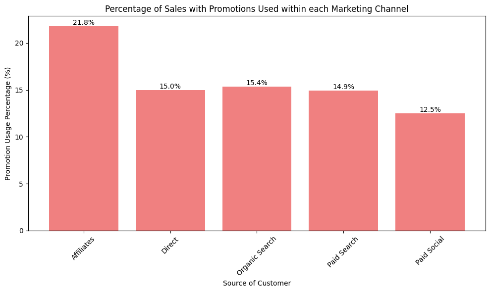

```python
# Step 1: Calculate total profit for each customer (1st Order Profit + Subsequent Order Profit)
merged_df['Total Profit'] = merged_df['1st Order Profit'] + merged_df['Subsequent Order Profit'] - merged_df["Total value of all promotions"]

# Step 2: Group by 'Source of Customer' to calculate the total profit and promotions for each channel
total_profit_by_channel = merged_df.groupby('Source of Customer')['Total Profit'].sum().reset_index()
promotion_usage_by_channel = merged_df.groupby('Source of Customer')['Total value of all promotions'].sum().reset_index()

# Step 3: Merge both DataFrames on 'Source of Customer'
merged_profit_promotion_df = pd.merge(total_profit_by_channel, promotion_usage_by_channel, on='Source of Customer')

# Step 4: Calculate the percentage of promotion usage for each channel
merged_profit_promotion_df['Promotion Usage Percentage'] = (merged_profit_promotion_df['Total value of all promotions'] / merged_profit_promotion_df['Total Profit']) * 100

# Step 5: Plot the promotion usage percentage for each channel
plt.figure(figsize=(10, 6))
bars = plt.bar(merged_profit_promotion_df['Source of Customer'], merged_profit_promotion_df['Promotion Usage Percentage'], color='lightcoral')

# Add percentage labels on bars
for bar in bars:
    height = bar.get_height()
    plt.text(bar.get_x() + bar.get_width()/2.0, height, f'{height:.1f}%', ha='center', va='bottom')

# Customize the plot
plt.title('Percentage of Sales with Promotions Used within each Marketing Channel')
plt.xlabel('Source of Customer')
plt.ylabel('Promotion Usage Percentage (%)')
plt.xticks(rotation=45)
plt.tight_layout()
plt.show()
```

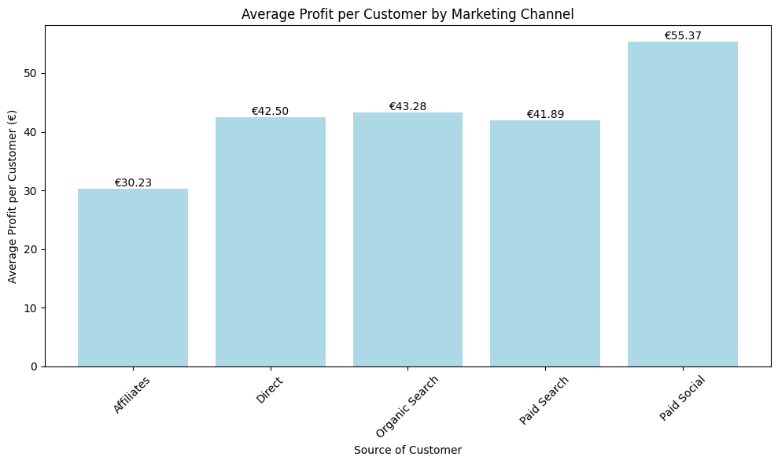

```python
import pandas as pd
import matplotlib.pyplot as plt

# Step 1: Calculate total profit for each customer (1st Order Profit + Subsequent Order Profit)
merged_df['Total Profit'] = merged_df['1st Order Profit'] + merged_df['Subsequent Order Profit'] - merged_df["Total value of all promotions"]

# Step 2: Group by 'Source of Customer' to calculate total profit and customer count for each channel
total_profit_by_channel = merged_df.groupby('Source of Customer')['Total Profit'].sum().reset_index()
customer_count_by_channel = merged_df.groupby('Source of Customer')['Customer ID'].count().reset_index()

# Step 3: Merge total profit and customer count DataFrames
merged_profit_customer_df = pd.merge(total_profit_by_channel, customer_count_by_channel, on='Source of Customer')
merged_profit_customer_df.rename(columns={'Customer ID': 'Customer Count'}, inplace=True)

# Step 4: Calculate the average profit per customer for each channel
merged_profit_customer_df['Average Profit per Customer'] = merged_profit_customer_df['Total Profit'] / merged_profit_customer_df['Customer Count']

# Step 5: Plot the average profit per customer for each channel
plt.figure(figsize=(10, 6))
bars = plt.bar(merged_profit_customer_df['Source of Customer'], merged_profit_customer_df['Average Profit per Customer'], color='lightblue')

# Add labels on bars
for bar in bars:
    height = bar.get_height()
    plt.text(bar.get_x() + bar.get_width()/2.0, height, f'€{height:.2f}', ha='center', va='bottom')

# Customize the plot
plt.title('Average Profit per Customer by Marketing Channel')
plt.xlabel('Source of Customer')
plt.ylabel('Average Profit per Customer (€)')
plt.xticks(rotation=45)
plt.tight_layout()
plt.show()
```

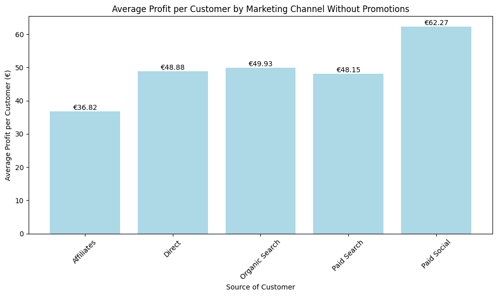

```python
import pandas as pd
import matplotlib.pyplot as plt

# Step 1: Calculate total profit for each customer (1st Order Profit + Subsequent Order Profit)
merged_df['Total Profit'] = merged_df['1st Order Profit'] + merged_df['Subsequent Order Profit']

# Step 2: Group by 'Source of Customer' to calculate total profit and customer count for each channel
total_profit_by_channel = merged_df.groupby('Source of Customer')['Total Profit'].sum().reset_index()
customer_count_by_channel = merged_df.groupby('Source of Customer')['Customer ID'].count().reset_index()

# Step 3: Merge total profit and customer count DataFrames
merged_profit_customer_df = pd.merge(total_profit_by_channel, customer_count_by_channel, on='Source of Customer')
merged_profit_customer_df.rename(columns={'Customer ID': 'Customer Count'}, inplace=True)

# Step 4: Calculate the average profit per customer for each channel
merged_profit_customer_df['Average Profit per Customer'] = merged_profit_customer_df['Total Profit'] / merged_profit_customer_df['Customer Count']

# Step 5: Plot the average profit per customer for each channel
plt.figure(figsize=(10, 6))
bars = plt.bar(merged_profit_customer_df['Source of Customer'], merged_profit_customer_df['Average Profit per Customer'], color='lightblue')

# Add labels on bars
for bar in bars:
    height = bar.get_height()
    plt.text(bar.get_x() + bar.get_width()/2.0, height, f'€{height:.2f}', ha='center', va='bottom')

# Customize the plot
plt.title('Average Profit per Customer by Marketing Channel Without Promotions')
plt.xlabel('Source of Customer')
plt.ylabel('Average Profit per Customer (€)')
plt.xticks(rotation=45)
plt.tight_layout()
plt.show()
```

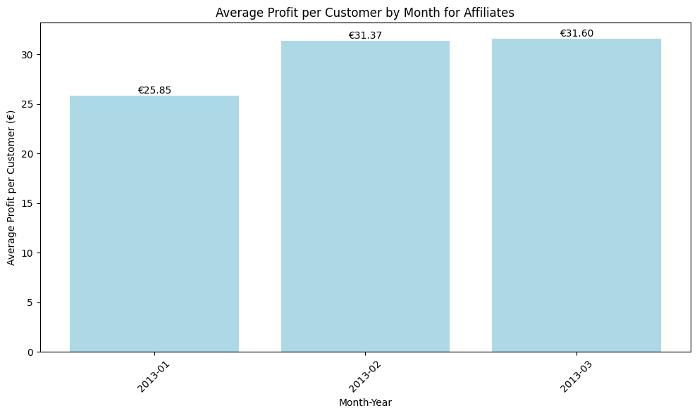

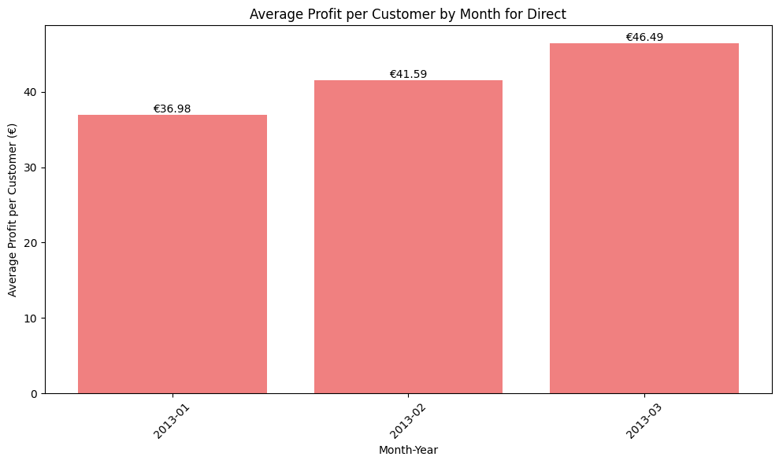

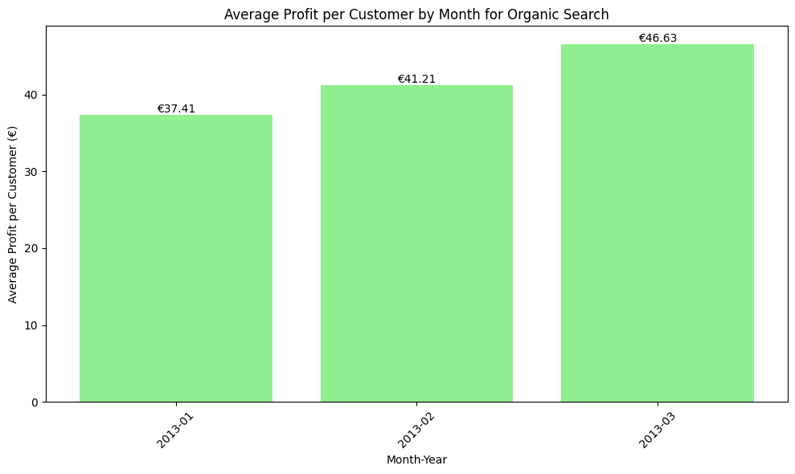

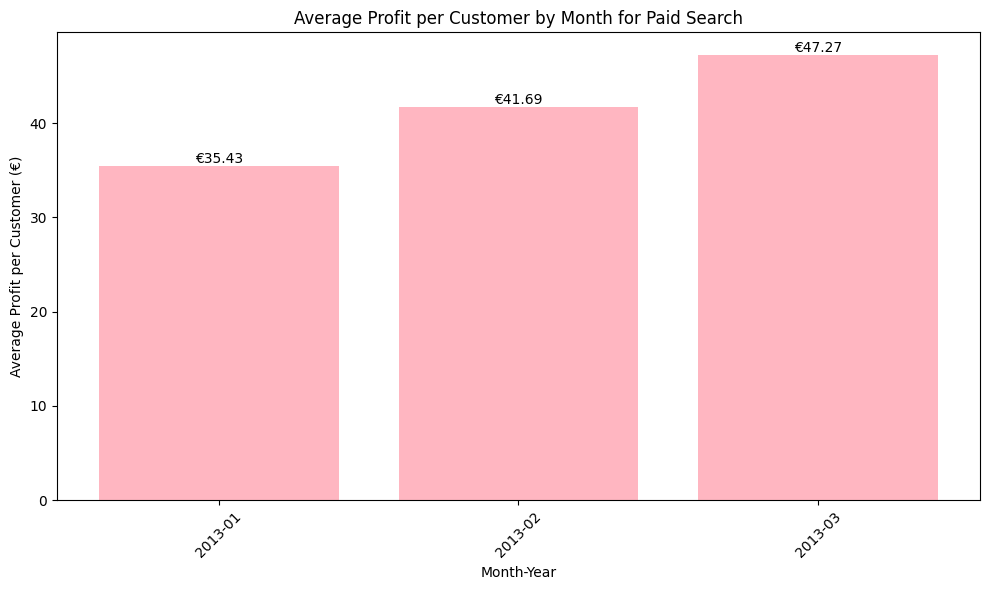

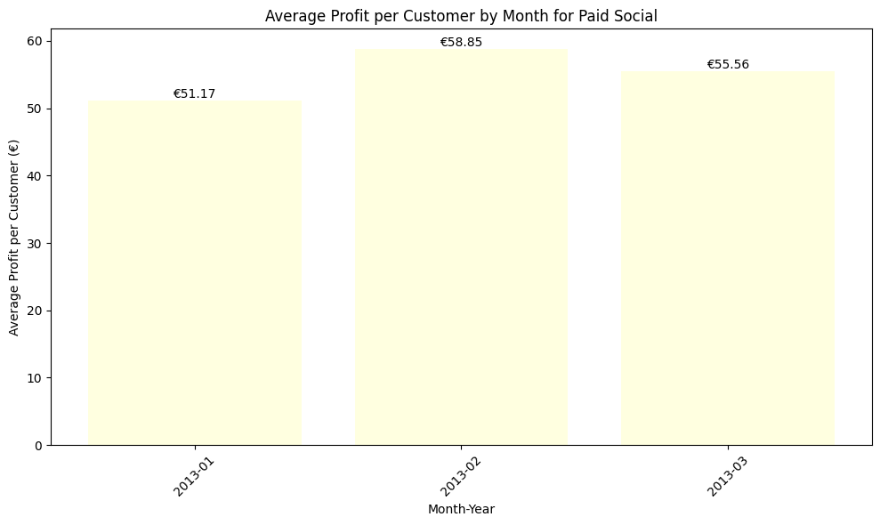

```python
import pandas as pd
import matplotlib.pyplot as plt

# Define colors for different channels
colors = ['lightblue', 'lightcoral', 'lightgreen', 'lightpink', 'lightyellow', 'lightgray']

# Step 1: Ensure 'Registration Date' is in datetime format and extract 'Month-Year'
merged_df['Registration Date'] = pd.to_datetime(merged_df['Registration Date'], dayfirst=True)
merged_df['Month-Year'] = merged_df['Registration Date'].dt.to_period('M')  # To ensure proper sorting by month

# Step 2: Calculate total profit for each customer (1st Order Profit + Subsequent Order Profit)
merged_df['Total Profit'] = merged_df['1st Order Profit'] + merged_df['Subsequent Order Profit'] - merged_df["Total value of all promotions"]

# Step 3: Group by 'Month-Year' and 'Source of Customer' to calculate total profit and customer count for each channel and month
monthly_total_profit = merged_df.groupby(['Month-Year', 'Source of Customer'])['Total Profit'].sum().reset_index()
monthly_customer_count = merged_df.groupby(['Month-Year', 'Source of Customer'])['Customer ID'].count().reset_index()

# Step 4: Merge the total profit and customer count DataFrames
monthly_profit_customer_df = pd.merge(monthly_total_profit, monthly_customer_count, on=['Month-Year', 'Source of Customer'])
monthly_profit_customer_df.rename(columns={'Customer ID': 'Customer Count'}, inplace=True)

# Step 5: Calculate the average profit per customer for each channel in each month
monthly_profit_customer_df['Average Profit per Customer'] = monthly_profit_customer_df['Total Profit'] / monthly_profit_customer_df['Customer Count']

# Step 6: Plot the average profit per customer by month and marketing channel with different colors
for idx, channel in enumerate(monthly_profit_customer_df['Source of Customer'].unique()):
    # Filter data for the current channel
    channel_data = monthly_profit_customer_df[monthly_profit_customer_df['Source of Customer'] == channel]

    # Plot the time series for the channel with a unique color
    plt.figure(figsize=(10, 6))
    bars = plt.bar(channel_data['Month-Year'].astype(str), channel_data['Average Profit per Customer'], color=colors[idx % len(colors)])

    # Add labels on bars
    for bar in bars:
        height = bar.get_height()
        plt.text(bar.get_x() + bar.get_width()/2.0, height, f'€{height:.2f}', ha='center', va='bottom')

    # Customize the plot
    plt.title(f'Average Profit per Customer by Month for {channel}')
    plt.xlabel('Month-Year')
    plt.ylabel('Average Profit per Customer (€)')
    plt.xticks(rotation=45)
    plt.tight_layout()
    plt.show()
```

**Key Findings**

#### **Forecast of Average Profit per Customers using Repeat Purchaser Rates**

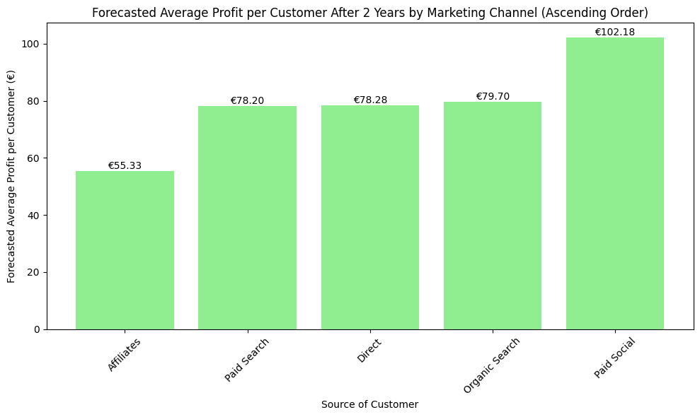

```python
import pandas as pd
import matplotlib.pyplot as plt

# Step 1: Calculate total profit for each customer (1st Order Profit + Subsequent Order Profit)
merged_df['Total Profit'] = merged_df['1st Order Profit'] + merged_df['Subsequent Order Profit'] - merged_df["Total value of all promotions"]

# Step 2: Calculate repeat purchase rate using Subsequent Orders Count
merged_df['Repeat Purchase Rate'] = merged_df['Subsequent Orders Count'] / (merged_df['Subsequent Orders Count'] + 1)

# Step 3: Assume the repeat purchase rate stays the same and calculate the forecasted sales per customer after 2 years
# We will assume that there are 8 potential purchase opportunities per year, so 16 in 2 years.
purchase_opportunities_in_2_years = 16

# Forecast future sales: Current 1st Order + Repeat Purchase Rate applied to future opportunities
merged_df['Forecasted Sales After 2 Years'] = 1 + (merged_df['Repeat Purchase Rate'] * purchase_opportunities_in_2_years)

# Step 4: Calculate the average profit per order (Total Profit / Total Orders)
merged_df['Average Profit per Order'] = merged_df['Total Profit'] / (merged_df['Subsequent Orders Count'] + 1)

# Step 5: Forecast the total profit after 2 years (Forecasted Sales * Average Profit per Order)
merged_df['Forecasted Profit After 2 Years'] = merged_df['Forecasted Sales After 2 Years'] * merged_df['Average Profit per Order']

# Step 6: Group by 'Source of Customer' to calculate the average forecasted profit per customer for each channel
forecasted_profit_by_channel = merged_df.groupby('Source of Customer')['Forecasted Profit After 2 Years'].mean().reset_index()

# Step 7: Sort the data in ascending order by 'Forecasted Profit After 2 Years'
forecasted_profit_by_channel = forecasted_profit_by_channel.sort_values(by='Forecasted Profit After 2 Years', ascending=True)

# Step 8: Plot the forecasted average profit per customer for each channel after 2 years
plt.figure(figsize=(10, 6))
bars = plt.bar(forecasted_profit_by_channel['Source of Customer'], forecasted_profit_by_channel['Forecasted Profit After 2 Years'], color='lightgreen')

# Add labels on bars
for bar in bars:
    height = bar.get_height()
    plt.text(bar.get_x() + bar.get_width()/2.0, height, f'€{height:.2f}', ha='center', va='bottom')

# Customize the plot
plt.title('Forecasted Average Profit per Customer After 2 Years by Marketing Channel (Ascending Order)')
plt.xlabel('Source of Customer')
plt.ylabel('Forecasted Average Profit per Customer (€)')
plt.xticks(rotation=45)
plt.tight_layout()
plt.show()
```

Now create same bar charts without promotion data:

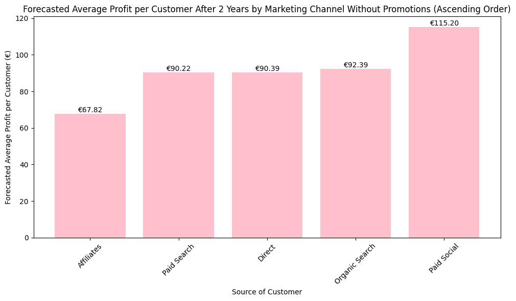

```python
import pandas as pd
import matplotlib.pyplot as plt

# Step 1: Calculate total profit for each customer (1st Order Profit + Subsequent Order Profit)
merged_df['Total Profit'] = merged_df['1st Order Profit'] + merged_df['Subsequent Order Profit']

# Step 2: Calculate repeat purchase rate using Subsequent Orders Count
merged_df['Repeat Purchase Rate'] = merged_df['Subsequent Orders Count'] / (merged_df['Subsequent Orders Count'] + 1)

# Step 3: Assume the repeat purchase rate stays the same and calculate the forecasted sales per customer after 2 years
# We will assume that there are 8 potential purchase opportunities per year, so 16 in 2 years.
purchase_opportunities_in_2_years = 16

# Forecast future sales: Current 1st Order + Repeat Purchase Rate applied to future opportunities
merged_df['Forecasted Sales After 2 Years'] = 1 + (merged_df['Repeat Purchase Rate'] * purchase_opportunities_in_2_years)

# Step 4: Calculate the average profit per order (Total Profit / Total Orders)
merged_df['Average Profit per Order'] = merged_df['Total Profit'] / (merged_df['Subsequent Orders Count'] + 1)

# Step 5: Forecast the total profit after 2 years (Forecasted Sales * Average Profit per Order)
merged_df['Forecasted Profit After 2 Years'] = merged_df['Forecasted Sales After 2 Years'] * merged_df['Average Profit per Order']

# Step 6: Group by 'Source of Customer' to calculate the average forecasted profit per customer for each channel
forecasted_profit_by_channel = merged_df.groupby('Source of Customer')['Forecasted Profit After 2 Years'].mean().reset_index()

# Step 7: Sort the data in ascending order by 'Forecasted Profit After 2 Years'
forecasted_profit_by_channel = forecasted_profit_by_channel.sort_values(by='Forecasted Profit After 2 Years', ascending=True)

# Step 8: Plot the forecasted average profit per customer for each channel after 2 years
plt.figure(figsize=(10, 6))
bars = plt.bar(forecasted_profit_by_channel['Source of Customer'], forecasted_profit_by_channel['Forecasted Profit After 2 Years'], color='pink')

# Add labels on bars
for bar in bars:
    height = bar.get_height()
    plt.text(bar.get_x() + bar.get_width()/2.0, height, f'€{height:.2f}', ha='center', va='bottom')

# Customize the plot
plt.title('Forecasted Average Profit per Customer After 2 Years by Marketing Channel Without Promotions (Ascending Order)')
plt.xlabel('Source of Customer')
plt.ylabel('Forecasted Average Profit per Customer (€)')
plt.xticks(rotation=45)
plt.tight_layout()
plt.show()
```

[figure not shown]

```python
import pandas as pd
import matplotlib.pyplot as plt

# Step 1: Calculate total profit without promotions (1st Order Profit + Subsequent Order Profit)
merged_df['Total Profit Without Promotions'] = merged_df['1st Order Profit'] + merged_df['Subsequent Order Profit']

# Step 2: Calculate total profit with promotions (subtract total value of promotions)
merged_df['Total Profit With Promotions'] = merged_df['Total Profit Without Promotions'] - merged_df['Total value of all promotions']

# Step 3: Calculate repeat purchase rate using Subsequent Orders Count
merged_df['Repeat Purchase Rate'] = merged_df['Subsequent Orders Count'] / (merged_df['Subsequent Orders Count'] + 1)

# Step 4: Assume the repeat purchase rate stays the same and calculate the forecasted sales per customer after 2 years
# We assume there are 8 purchase opportunities per year, so 16 in 2 years.
purchase_opportunities_in_2_years = 16

# Forecast future sales: Current 1st Order + Repeat Purchase Rate applied to future opportunities
merged_df['Forecasted Sales After 2 Years'] = 1 + (merged_df['Repeat Purchase Rate'] * purchase_opportunities_in_2_years)

# Step 5: Calculate the average profit per order (without and with promotions)
merged_df['Average Profit per Order Without Promotions'] = merged_df['Total Profit Without Promotions'] / (merged_df['Subsequent Orders Count'] + 1)
merged_df['Average Profit per Order With Promotions'] = merged_df['Total Profit With Promotions'] / (merged_df['Subsequent Orders Count'] + 1)

# Step 6: Forecast the total profit after 2 years (Forecasted Sales * Average Profit per Order)
merged_df['Forecasted Profit After 2 Years Without Promotions'] = merged_df['Forecasted Sales After 2 Years'] * merged_df['Average Profit per Order Without Promotions']
merged_df['Forecasted Profit After 2 Years With Promotions'] = merged_df['Forecasted Sales After 2 Years'] * merged_df['Average Profit per Order With Promotions']

# Step 7: Group by 'Source of Customer' to calculate the average forecasted profit per customer for each channel
forecasted_profit_by_channel = merged_df.groupby('Source of Customer')[['Forecasted Profit After 2 Years Without Promotions', 'Forecasted Profit After 2 Years With Promotions']].mean().reset_index()

# Step 8: Sort the data in ascending order by 'Forecasted Profit After 2 Years With Promotions'
forecasted_profit_by_channel = forecasted_profit_by_channel.sort_values(by='Forecasted Profit After 2 Years With Promotions', ascending=True)

# Step 9: Plot the dual bar chart for forecasted profit with and without promotions
plt.figure(figsize=(10, 6))
bar_width = 0.35  # Width of each bar

# Positions for the bars
r1 = range(len(forecasted_profit_by_channel))
r2 = [x + bar_width for x in r1]

# Bars for 'Without Promotions'
plt.bar(r1, forecasted_profit_by_channel['Forecasted Profit After 2 Years Without Promotions'], color='blue', width=bar_width, label='Without Promotions')

# Bars for 'With Promotions'
plt.bar(r2, forecasted_profit_by_channel['Forecasted Profit After 2 Years With Promotions'], color='orange', width=bar_width, label='With Promotions')

# Add labels on bars (Without Promotions)
for i in range(len(r1)):
    height = forecasted_profit_by_channel['Forecasted Profit After 2 Years Without Promotions'][i]
    plt.text(r1[i], height, f'€{height:.2f}', ha='center', va='bottom')

# Add labels on bars (With Promotions)
for i in range(len(r2)):
    height = forecasted_profit_by_channel['Forecasted Profit After 2 Years With Promotions'][i]
    plt.text(r2[i], height, f'€{height:.2f}', ha='center', va='bottom')

# Customize the plot
plt.title('Forecasted Average Profit per Customer After 2 Years (With and Without Promotions)')
plt.xlabel('Source of Customer')
plt.ylabel('Forecasted Average Profit per Customer (€)')
plt.xticks([r + bar_width / 2 for r in range(len(forecasted_profit_by_channel))], forecasted_profit_by_channel['Source of Customer'], rotation=45)
plt.legend()
plt.tight_layout()
plt.show()
```

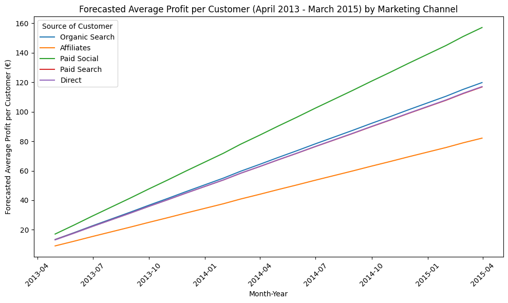

```python
import pandas as pd
import numpy as np
import matplotlib.pyplot as plt

# Step 1: Calculate total profit for each customer (1st Order Profit + Subsequent Order Profit)
merged_df['Total Profit'] = merged_df['1st Order Profit'] + merged_df['Subsequent Order Profit'] - merged_df["Total value of all promotions"]

# Step 2: Calculate repeat purchase rate using Subsequent Orders Count
merged_df['Repeat Purchase Rate'] = merged_df['Subsequent Orders Count'] / (merged_df['Subsequent Orders Count'] + 1)

# Step 3: Simulate future months starting from April 2013
# Simulate 24 months from April 2013 (2 years into the future)
months_in_2_years = 24
time_periods = pd.date_range(start='2013-04-01', periods=months_in_2_years, freq='ME')

# Step 4: Calculate the average profit per order (Total Profit / Total Orders)
merged_df['Average Profit per Order'] = merged_df['Total Profit'] / (merged_df['Subsequent Orders Count'] + 1)

# Step 5: Forecast profit per customer for each month over the next 2 years
forecasted_profit_per_month = {}

# Loop over each marketing channel and simulate the forecasted profit
for channel in merged_df['Source of Customer'].unique():
    # Get the subset of the data for the current channel
    channel_data = merged_df[merged_df['Source of Customer'] == channel]

    # Get the average repeat purchase rate and profit per order for the channel
    repeat_rate = channel_data['Repeat Purchase Rate'].mean()
    avg_profit_per_order = channel_data['Average Profit per Order'].mean()

    # Simulate future sales over 24 months (1st purchase + repeat rate applied to future months)
    forecasted_sales = [1 + (repeat_rate * month) for month in range(1, months_in_2_years + 1)]

    # Calculate the forecasted profit by multiplying sales by the average profit per order
    forecasted_profit = np.array(forecasted_sales) * avg_profit_per_order

    # Store the forecasted profit for the current channel
    forecasted_profit_per_month[channel] = forecasted_profit

# Step 6: Plot the time series for each marketing channel
plt.figure(figsize=(10, 6))

for channel, profit_forecast in forecasted_profit_per_month.items():
    plt.plot(time_periods, profit_forecast, label=channel)

# Customize the plot
plt.title('Forecasted Average Profit per Customer (April 2013 - March 2015) by Marketing Channel')
plt.xlabel('Month-Year')
plt.ylabel('Forecasted Average Profit per Customer (€)')
plt.xticks(rotation=45)
plt.legend(title='Source of Customer')
plt.tight_layout()
plt.show()
```

#### Total profits after 2 years forecasting using original acquisition rates and uniform acquisition rates

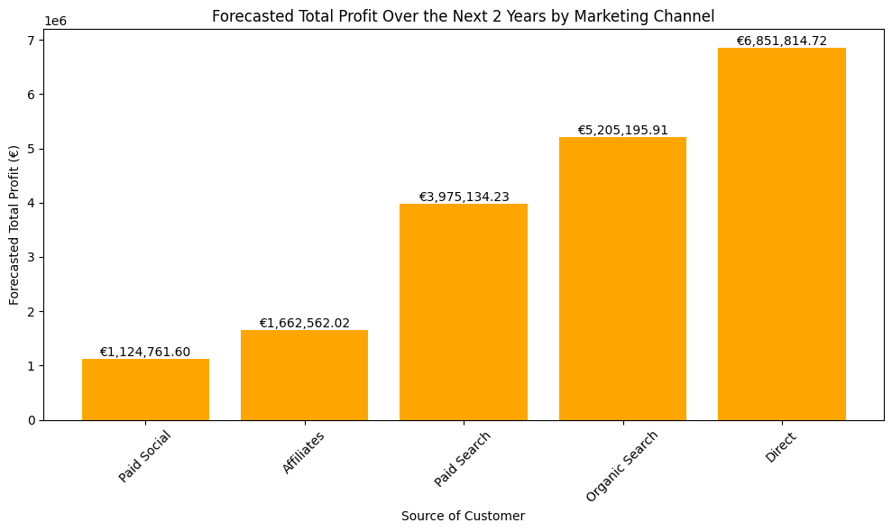

```python
import pandas as pd
import matplotlib.pyplot as plt

# Step 1: Calculate total profit for each customer (1st Order Profit + Subsequent Order Profit - Total value of all promotions)
merged_df['Total Profit'] = merged_df['1st Order Profit'] + merged_df['Subsequent Order Profit'] - merged_df['Total value of all promotions']

# Step 2: Calculate repeat purchase rate using Subsequent Orders Count
merged_df['Repeat Purchase Rate'] = merged_df['Subsequent Orders Count'] / (merged_df['Subsequent Orders Count'] + 1)

# Step 3: Assume the repeat purchase rate stays the same and calculate the forecasted sales per customer after 2 years
# We assume that there are 8 potential purchase opportunities per year, so 16 in 2 years.
purchase_opportunities_in_2_years = 16
merged_df['Forecasted Sales After 2 Years'] = 1 + (merged_df['Repeat Purchase Rate'] * purchase_opportunities_in_2_years)

# Step 4: Calculate the average profit per order (Total Profit / Total Orders)
merged_df['Average Profit per Order'] = merged_df['Total Profit'] / (merged_df['Subsequent Orders Count'] + 1)

# Step 5: Forecast the total profit after 2 years (Forecasted Sales * Average Profit per Order)
merged_df['Forecasted Profit After 2 Years'] = merged_df['Forecasted Sales After 2 Years'] * merged_df['Average Profit per Order']

# Step 6: Calculate the number of users acquired by each channel during the observed period
user_count_by_channel = merged_df.groupby('Source of Customer')['Customer ID'].count().reset_index()
user_count_by_channel.rename(columns={'Customer ID': 'Users Acquired'}, inplace=True)

# Step 7: Forecast the total number of users acquired over the next 2 years
# We assume the same rate of acquisition as observed historically
user_count_by_channel['Forecasted Users in 2 Years'] = user_count_by_channel['Users Acquired'] * (2 / (3/12))  # Extrapolate for 2 years, based on the 3-month observation window

# Step 8: Group by 'Source of Customer' to calculate the average forecasted profit per customer for each channel
forecasted_profit_by_channel = merged_df.groupby('Source of Customer')['Forecasted Profit After 2 Years'].mean().reset_index()

# Step 9: Merge user count and forecasted profit data
forecasted_total_profit = pd.merge(user_count_by_channel, forecasted_profit_by_channel, on='Source of Customer')

# Step 10: Calculate the forecasted total profit for each channel (Forecasted Users * Average Forecasted Profit per Customer)
forecasted_total_profit['Total Profit in 2 Years'] = forecasted_total_profit['Forecasted Users in 2 Years'] * forecasted_total_profit['Forecasted Profit After 2 Years']

# Step 11: Sort the data in ascending order by 'Total Profit in 2 Years'
forecasted_total_profit = forecasted_total_profit.sort_values(by='Total Profit in 2 Years', ascending=True)

combined_total_profit_original_rate = forecasted_total_profit['Total Profit in 2 Years'].sum()

# Step 12: Plot the forecasted total profit by channel
plt.figure(figsize=(10, 6))
bars = plt.bar(forecasted_total_profit['Source of Customer'], forecasted_total_profit['Total Profit in 2 Years'], color='orange')

# Add labels on bars
for bar in bars:
    height = bar.get_height()
    plt.text(bar.get_x() + bar.get_width()/2.0, height, f'€{height:,.2f}', ha='center', va='bottom')

# Customize the plot
plt.title('Forecasted Total Profit Over the Next 2 Years by Marketing Channel')
plt.xlabel('Source of Customer')
plt.ylabel('Forecasted Total Profit (€)')
plt.xticks(rotation=45)
plt.tight_layout()
plt.show()
```

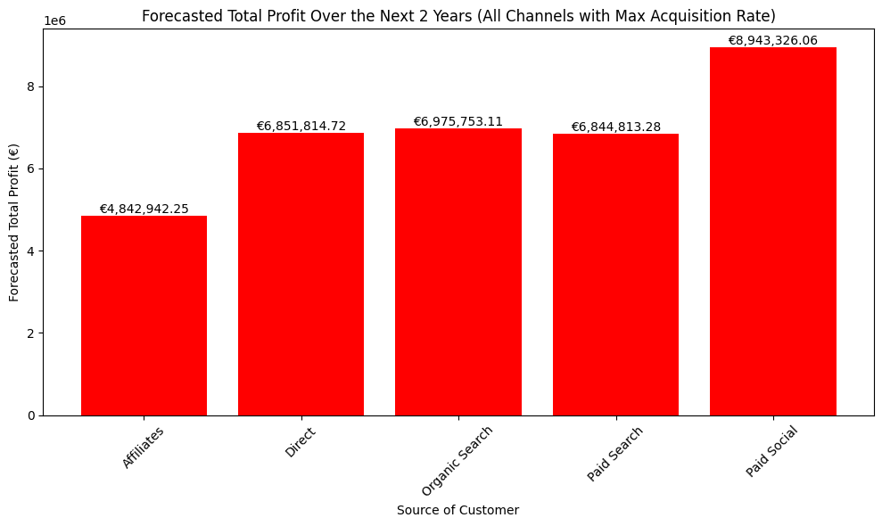

```python
import pandas as pd
import matplotlib.pyplot as plt

# Step 1: Calculate total profit for each customer (1st Order Profit + Subsequent Order Profit - Total value of all promotions)
merged_df['Total Profit'] = merged_df['1st Order Profit'] + merged_df['Subsequent Order Profit'] - merged_df['Total value of all promotions']

# Step 2: Calculate repeat purchase rate using Subsequent Orders Count
merged_df['Repeat Purchase Rate'] = merged_df['Subsequent Orders Count'] / (merged_df['Subsequent Orders Count'] + 1)

# Step 3: Assume the repeat purchase rate stays the same and calculate the forecasted sales per customer after 2 years
# We assume that there are 8 potential purchase opportunities per year, so 16 in 2 years.
purchase_opportunities_in_2_years = 16
merged_df['Forecasted Sales After 2 Years'] = 1 + (merged_df['Repeat Purchase Rate'] * purchase_opportunities_in_2_years)

# Step 4: Calculate the average profit per order (Total Profit / Total Orders)
merged_df['Average Profit per Order'] = merged_df['Total Profit'] / (merged_df['Subsequent Orders Count'] + 1)

# Step 5: Forecast the total profit after 2 years (Forecasted Sales * Average Profit per Order)
merged_df['Forecasted Profit After 2 Years'] = merged_df['Forecasted Sales After 2 Years'] * merged_df['Average Profit per Order']

# Step 6: Calculate the number of users acquired by each channel during the observed period
user_count_by_channel = merged_df.groupby('Source of Customer')['Customer ID'].count().reset_index()
user_count_by_channel.rename(columns={'Customer ID': 'Users Acquired'}, inplace=True)

# Step 7: Identify the maximum user acquisition rate (maximum users acquired by any channel)
max_acquisition_rate = user_count_by_channel['Users Acquired'].max()

# Step 8: Apply the maximum acquisition rate to all channels for the next 2 years
# We assume that all channels will acquire users at this same maximum rate over the next 2 years
user_count_by_channel['Forecasted Users in 2 Years'] = max_acquisition_rate * (2 / (3/12))  # Extrapolate for 2 years based on a 3-month observation period

# Step 9: Group by 'Source of Customer' to calculate the average forecasted profit per customer for each channel
forecasted_profit_by_channel = merged_df.groupby('Source of Customer')['Forecasted Profit After 2 Years'].mean().reset_index()

# Step 10: Merge user count and forecasted profit data
forecasted_total_profit = pd.merge(user_count_by_channel, forecasted_profit_by_channel, on='Source of Customer')

# Step 11: Calculate the forecasted total profit for each channel (Max acquisition rate * Average Forecasted Profit per Customer)
forecasted_total_profit['Total Profit in 2 Years'] = forecasted_total_profit['Forecasted Users in 2 Years'] * forecasted_total_profit['Forecasted Profit After 2 Years']

# Step 12: Calculate the combined total profit from all channels
combined_total_profit_same_rate = forecasted_total_profit['Total Profit in 2 Years'].sum()


# Step 14: Plot the forecasted total profit by channel
plt.figure(figsize=(10, 6))
bars = plt.bar(forecasted_total_profit['Source of Customer'], forecasted_total_profit['Total Profit in 2 Years'], color='red')

# Add labels on bars
for bar in bars:
    height = bar.get_height()
    plt.text(bar.get_x() + bar.get_width()/2.0, height, f'€{height:,.2f}', ha='center', va='bottom')

# Customize the plot
plt.title('Forecasted Total Profit Over the Next 2 Years (All Channels with Max Acquisition Rate)')
plt.xlabel('Source of Customer')
plt.ylabel('Forecasted Total Profit (€)')
plt.xticks(rotation=45)
plt.tight_layout()
plt.show()
```

```
Combined Total Profit for All Channels Over the Next 2 Years (If all channels acquire users at the original acquisition rate): €18,819,468.47
Combined Total Profit for All Channels Over the Next 2 Years (If all channels acquire users at the same acquisition rate as Direct channel): €34,458,649.43
```

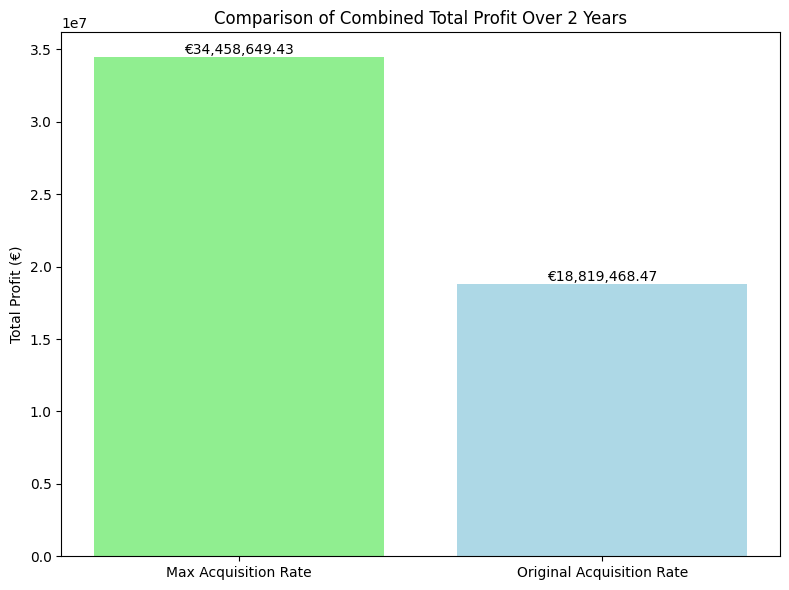

```python
print(f"Combined Total Profit for All Channels Over the Next 2 Years (If all channels acquire users at the original acquisition rate): €{combined_total_profit_original_rate:,.2f}")

print(f"Combined Total Profit for All Channels Over the Next 2 Years (If all channels acquire users at the same acquisition rate as Direct channel): €{combined_total_profit_same_rate:,.2f}")


# Labels for the bar chart
labels = ['Max Acquisition Rate', 'Original Acquisition Rate']

# Data for the bar chart
values = [combined_total_profit_same_rate, combined_total_profit_original_rate]

# Plotting the bar chart
plt.figure(figsize=(8, 6))
bars = plt.bar(labels, values, color=['lightgreen', 'lightblue'])

# Add labels on the bars
for bar in bars:
    height = bar.get_height()
    plt.text(bar.get_x() + bar.get_width() / 2.0, height, f'€{height:,.2f}', ha='center', va='bottom')

# Customize the plot
plt.title('Comparison of Combined Total Profit Over 2 Years')
plt.ylabel('Total Profit (€)')
plt.tight_layout()

# Display the plot
plt.show()
```

## Conclusion

Through this detailed analysis of the retailer's customer data, several important insights and trends emerged, providing actionable steps for optimizing customer acquisition and profitability across marketing channels.

### Key Findings:

#### Customer Demographics:

- The majority of customers are male, but gender did not significantly impact acquisition rates across different marketing channels.
- The primary customer base falls between the ages of **25-35** and **36-45**, indicating that tailoring marketing efforts to these age groups would likely yield the best results.

#### Repeat Purchase Behavior:

- Gender did not play a significant role in the likelihood of repeat purchases, with a difference of less than 2% between male and female customers.
- Age also showed little variation in repeat purchases, reinforcing that demographic factors alone may not drive customer loyalty.
- However, repeat purchase behavior fluctuated with customer loyalty, peaking around **weeks 16-18** before declining after **week 20**. This suggests that targeted retention strategies should be introduced after 20 weeks to maintain engagement and drive repeat purchases.

#### Contactability and Repeat Purchases:

- Whether a customer was contactable did not make a significant difference in repeat purchase rates, with **1% more non-contactable customers** making repeat purchases than those who were contactable. This suggests that other factors may have a stronger influence on customer loyalty than direct marketing efforts.

### Channel-Specific Insights:

- **Affiliates** and **Paid Social** channels had lower customer acquisition rates but exhibited higher repeat purchase rates compared to other channels. For instance, **Paid Social** had a **55.1% repeat purchase rate**, the highest among all channels.
- Conversely, **Direct** had the highest acquisition rate and customer base, but this did not translate into the highest repeat purchase rate.
- **Paid Search** had the highest acquisition rate for female customers, while **Affiliates** performed best for male customers.

### Channel Profitability:

- While **Direct** was the most profitable channel in terms of total orders and acquisition volume, **Paid Social** delivered the highest **average profit per customer** at **€55.37**.
- **Affiliates**, despite having the second-highest repeat order rate, had the **lowest average profit per customer** at **€30.23**, possibly suggesting that this channel drives customers toward lower-value products.
- **Promotional Usage** varied across channels, with **Affiliates** showing the highest reliance on promotions and **Paid Social** the least. This emphasizes the strong performance of **Paid Social** in terms of profitability without heavy reliance on discounts.

### Future Forecast:

- A forecast based on **Repeat Purchase Rates** over the next **2 years** revealed that **Paid Social** would continue to be the most profitable on a per-customer basis, with an average profit of **€102.18** per customer. **Affiliates**, however, remained the least profitable at **€55** per customer.
- If current acquisition rates continue, **Direct** and **Organic Search** will drive the most total profit over the next two years. However, if all channels were to grow at the same rate as the **Direct** channel, **Paid Social** would take the lead, generating a projected total profit of **€8,943,326**.

### Recommendations:

1. **Increase Focus on Paid Social:**
   - Despite being the lowest in terms of customer acquisition, **Paid Social** has demonstrated the highest profitability per customer and repeat purchase rates. The retailer should consider increasing investment in **Paid Social** to capitalize on this high customer loyalty and profit potential.
2. **Target Affiliates More Strategically:**
   - While **Affiliates** show a strong repeat purchase rate, the low profit per customer suggests that customers acquired through this channel may be purchasing lower-value items. The retailer could explore ways to incentivize higher-value purchases through **Affiliates** or reframe how affiliate marketing is utilized.
3. **Retention Strategies for Long-Term Loyalty:**
   - With subsequent orders dropping after **20 weeks** of customer loyalty, the retailer could implement targeted retention campaigns, such as personalized offers, loyalty rewards, or exclusive discounts, to re-engage customers beyond the 20-week mark and encourage long-term loyalty.
4. **Maximizing Channel Growth:**
   - If all channels were to grow at the same rate as **Direct**, the total profit over the next two years could almost double to **€34,458,649**, with **Paid Social** leading the way. Therefore, increasing the growth rates of **Paid Social** and **Affiliates** should be a priority for maximizing overall profitability.

### Final Thoughts:

This analysis has provided a comprehensive view of how the retailer's marketing channels perform in terms of customer acquisition, repeat purchases, and profitability. By focusing on channels like **Paid Social** that exhibit both high loyalty and profitability, while also fine-tuning strategies for channels like **Affiliates** and **Direct**, the retailer can better allocate resources and efforts to drive higher profits in the future.